# CSCI E-63C: Final Exam/Project

Ethan Mallove

Wed Dec 11, 2019

# Preface

> For the final exam/project we will develop classification models using several approaches and compare their performance on a new dataset that is a subset of one of the datasets used in machine learning common task framework (CTF) competitions. A copy of it split into training (`final-data-train.csv`, with outcome `response` available) and test (`final-data-test.csv`, stripped of the outcome, for prediction purposes only) datasets is available on our course website in Canvas as a zip-archive of all associated files.

> Please notice, that at the end of this final exam/project you will be asked, in addition to the Rmarkdown and HTML files, to also make predictions for the observations in the *test* (not training!) dataset and upload them into Canvas as well. The expected format for the file with predictions for test dataset is two columns of comma-separated values, one row per observation in *test* dataset, first column – the observation identifier (column `id` in test dataset) and the second column – your best model predictions for each observation in the *test* dataset as Y/N indicator. To illustrate expected format the zip archive contains also a couple of examples of test predictions in this format for your reference as well (`predictions-*.csv` files in `predictions-examples` sub-folder in zip-archive).

> One more time, to iterate and emphasize, please notice that this time your submission must consist of the following *three* (not just two, Rmd+html, as usual) items:
> - Rmarkdown *.Rmd file with all the calculations you want to receive credit for,
> - HTML version of the output generated by your *.Rmd file, and
> - **predictions** for the **test** dataset in comma-separated values (CSV) format (file name **must** have *.csv extension for the file to load in Canvas)

> The teaching team invites you to load your predictions (just predictions, just for the test dataset according to the file format shown in the sample files in the zip-archive) into Canvas repeatedly as you work on your models and improve them over the course of this week. At least daily (or more frequently as we see fit) we will download predictions loaded by everyone by that time and compile a leaderboard in html format of all of them sorted by their accuracy as compared to the true values of the outcome for the test dataset (along with their sensitivity, specificity, etc.). This list will be made of all of them sorted by their accuracy as compared to the true values of the outcome for the test dataset (along with their sensitivity, specificity, etc.). This list will be made available on our course website in Canvas for everyone in this class in order to see how the performance of their models compares across the rest of the models built by other students in the class. The first version of the leaderboard posted on the course website at the time when final exam is made available starts with predictions made by those few example files provided in the zip-archive (coin flip, majority vote, etc. – what do you think Charlie Brown is using to make the predictions?). Those should be pretty easy to improve upon.

> It is 100% up to you whether you want to upload your model predictions over the course of this week, how frequently you want to do it and what you want its results to be called in the leaderboard posted for everyone in the class to see. We will use the name of the 2nd column in the file with predictions (the one containing Y/N values, not the numerical ids of the observations) as the model name listed in the leaderboard. If you prefer not to use your name, choose something else instead, sufficiently unique so that it is easier for you to spot your result among all others. Once again, please check out sample files of dull (majority vote, coin flip, etc.) predictions we have made available and consider how they show up in the leaderboard html file already posted on Canvas website. Once you are done with final you are expected to load predictions from your best model into Canvas – that is part of your points total as explained below.

> Lastly, the size of this dataset can make some of the modeling techniques run slower than what we were typically encountering in this class. You may find it helpful to do some of the exploration and model tuning on multiple random samples of smaller size as you decide on useful ranges of parameters/modeling choices, and then only perform a final run of fully debugged and working code on the full dataset. Please see also the afterword below on the computational demands of this problem set.

# Problem 1: univariate and unsupervised analysis (20 points)

> Download and read training and test data into R and prepare graphical and numerical summaries of it: e.g. histograms of continuous attributes, contingency tables of categorical variables, scatterplots of continuous attributes with some of the categorical variables indicated by color/symbol shape, etc. Whatever you find helpful to think about properties of the data you are about to start using for fitting classification models.

```r
finalExamDatFull <- read.csv("final-data-train.csv",sep=",")
nObs <- length(finalExamDatFull[,1])
randomIds = sample(1:nObs, size = floor(nObs/10))
finalExamDat <- finalExamDatFull[randomIds,]
summary(finalExamDat)
```

```
##  response       id         wc            zwp         wi
##  N:2319   Min.   :   142   a:   1   N      :1156   gmz:2834
##  Y: 780   1st Qu.:148906   b: 970   R      : 980   gnq: 265
##           Median :292174   c: 122   S      : 342
##           Mean   :295159   d:1913   O      : 237
##           3rd Qu.:445134   e:  83   U      : 138
##           Max.   :594320   f:  10   T      :  87
##                                     (Other): 159
##       dtj             bnf            qh        ent           sci
##  Min.   :0.000   J      :971   Min.   :1.310   A:2482   Min.   :1.224
##  1st Qu.:2.828   K      :838   1st Qu.:1.661   B: 617   1st Qu.:1.351
##  Median :3.317   I      :614   Median :1.758            Median :1.373
##  Mean   :3.025   L      :385   Mean   :1.800            Mean   :1.374
##  3rd Qu.:3.606   M      :141   3rd Qu.:1.893            3rd Qu.:1.397
##  Max.   :3.742   H      :139   Max.   :3.349            Max.   :1.566
##                  (Other): 11
##       ypz               bw         tdt             sb        ox
##  Min.   : 0.000   Min.   :0.1414   kc: 318   s2     :2865   bf:1346
##  1st Qu.: 1.000   1st Qu.:0.3162   kv: 100   s8     :  62   fy: 922
##  Median : 7.000   Median :0.3742   sm: 975   s6     :  54   ix: 171
##  Mean   : 6.623   Mean   :0.3781   zp:1706   s5     :  44   jl: 660
##  3rd Qu.:11.000   3rd Qu.:0.4000             s1     :  25
##  Max.   :17.000   Max.   :0.7874             s3     :  25
##                                              (Other):  24
##    xt       np             ku             is
##  dgk: 159   j:2344   z      :1052   Min.   : 0.003504
##  fcc: 659   k: 755   y      : 715   1st Qu.: 0.851765
##  gcn:   1            x      : 444   Median : 1.775400
##  mrm:  42            u      : 329   Mean   : 2.104946
##  ntb:2238            w      : 247   3rd Qu.: 3.045900
##                      v      : 123   Max.   :10.185000
##                      (Other): 189
```

Execution [wall clock] time for this code chunk: 0.25 seconds

```r
convertFactorsToNumbers <- function(v) {
  # prcomp needs numeric vars, not factors.
  #
  # > sapply(v, class)
  #  response        id        wc       zwp        wi       dtj       bnf        qh       ent       sci       ypz        bw       tdt        sb        ox        xt        np        ku        is
  #  "factor" "integer"  "factor"  "factor"  "factor" "numeric"  "factor" "numeric"  "factor" "numeric" "integer" "numeric"  "factor"  "factor"  "factor"  "factor"  "factor"  "factor" "numeric"

  # Keep a copy of both numeric data and factor (character, categorical) data
  vNumeric <- v

  #vNumeric$response <- as.numeric(v$response)
  #vNumeric$response <- lapply(v$response, FUN = function(x) x-1)

  # Some libs seem to want not just any numeric, but 0 and 1.
  vNumeric$response <- unlist(lapply(as.character(v$response), FUN = function(x) ifelse(x == "N", 0, 1)))

  # Convert factors to numbers
  vNumeric$wc   <- as.numeric(v$wc)
  vNumeric$zwp  <- as.numeric(v$zwp)
  vNumeric$wi   <- as.numeric(v$wi)
  vNumeric$bnf  <- as.numeric(v$bnf)
  vNumeric$ent  <- as.numeric(v$ent)
  vNumeric$tdt  <- as.numeric(v$tdt)
  vNumeric$sb   <- as.numeric(v$sb)
  vNumeric$ox   <- as.numeric(v$ox)
  vNumeric$xt   <- as.numeric(v$xt)
  vNumeric$np   <- as.numeric(v$np)
  vNumeric$ku   <- as.numeric(v$ku)

  return(vNumeric)
}
```

Execution [wall clock] time for this code chunk: 0 seconds

```r
# Use splitBy=1 to run use the full test (without shrinking the data set for shorter run-time)
getTestData <- function(splitBy = 5, splitTrainingAndTestBy = 2) {

  # Convert factors to numeric
  finalExamDatNumeric <- convertFactorsToNumbers(finalExamDatFull)

  nObs <- length(finalExamDatNumeric[,1])
  subsetIds = sample(1:nObs, size = floor(nObs/splitBy))
  finalExamDatSubset <- finalExamDatNumeric[subsetIds,]

  subsetLen  <- length(finalExamDatSubset[,1])
  trainIds   <- sample(1:subsetLen, size = floor(subsetLen/splitTrainingAndTestBy))
  ncols      <- ncol(finalExamDatSubset)
  xyzTrain   <- finalExamDatSubset[trainIds,2:ncols]
  classTrain <- finalExamDatSubset[trainIds,1]
  xyzTest    <- finalExamDatSubset[-trainIds,2:ncols]
  classTest  <- finalExamDatSubset[-trainIds,1]

  return ( list(
    "xyzTest"    = xyzTest,
    "xyzTrain"   = xyzTrain,
    "classTest"  = classTest,
    "classTrain" = classTrain
  ))
}
# r <- getTestData(splitBy = 1, splitTrainingAndTestBy = 1)
```

Execution [wall clock] time for this code chunk: 0 seconds

```r
# > count(pred$class)
#   x freq
# 1 0  860
# 2 1  173
# > count(classTest)
#   x freq
# 1 0  785
# 2 1  248
# > tbl <- addmargins(tbl)
# > tbl
# classTest    0    1  Sum
#       0    749   36  785
#       1    111  137  248
#       Sum  860  173 1033

# Thus -- our cross-tabulation function (table()) gives us the following
#   TN, FN, TP, and FP in the 2x2 confusion matrix
# classTest    0    1  Sum
#       0     TN   FP  785
#       1     FN   TP  248
#       Sum  860  173 1033

computeErrorRate <- function (myTable) {
  return (1 - sum(diag(myTable)) / sum(myTable))
}

computeAccuracy <- function (myTable) {
  return (sum(diag(myTable)) / sum(myTable))
}

# TP / (TP + FP)
computePrecision <- function (myTable) {
  return (myTable[2,2] / (tbl[2,2] + tbl[1,2]))
}

# TP / (TP + FN) !!
# FIXME: Why are false negatives to high -- leading to poor sensitivity?
computeSensitivity <- function (myTable) {
  return (myTable[2,2] / (myTable[2,2] + myTable[2,1]))
}

# TN / (TN + FP)
computeSpecificity <- function (myTable) {
  return (myTable[1,1] / (myTable[1,1] + myTable[1,2]))
}

printAllConfusionMatrixStats <- function(myTable) {
  print(paste("Accuracy: ", computeAccuracy(myTable)))
  print(paste("Sensitivity: ", computeSensitivity(myTable)))
  print(paste("Specificity: ", computeSpecificity(myTable)))
  print(paste("Precision: ", computePrecision(myTable)))
}
```

Execution [wall clock] time for this code chunk: 0.01 seconds

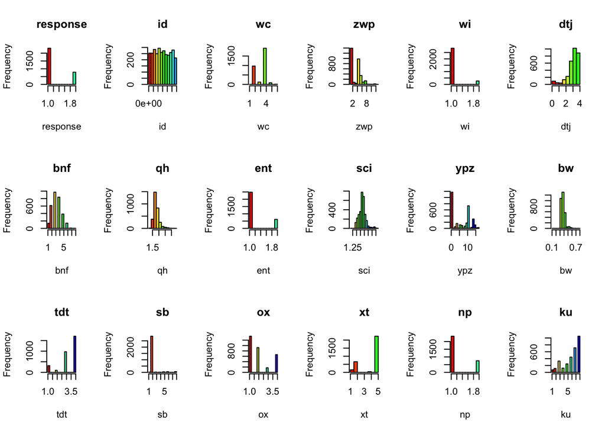

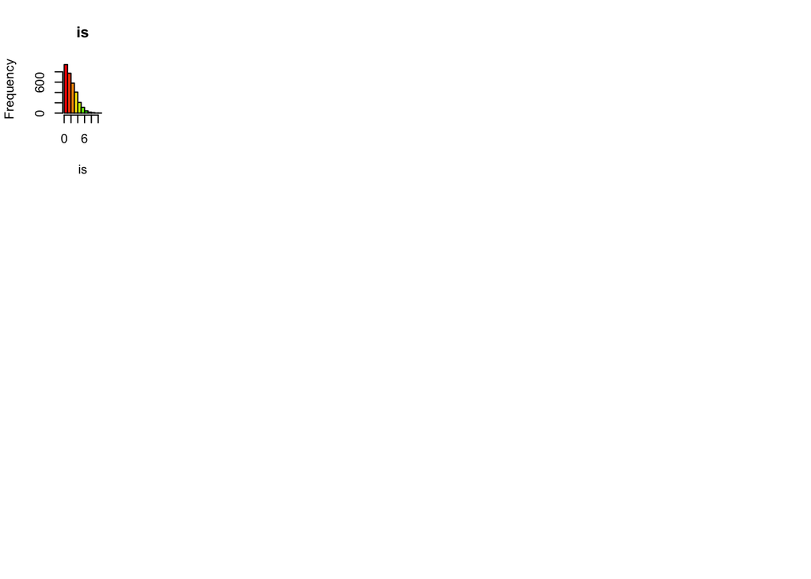

```r
colNames <- c("response","id","wc","zwp","wi","dtj","bnf","qh","ent","sci","ypz","bw","tdt","sb","ox","xt","np","ku","is")
colnames(finalExamDat) <- colNames

par(mfrow=c(3, floor(length(colNames)/3)))
for (c in colNames) {

  # Convert non-numeric columns (e.g., response) to numeric
  hist(as.numeric(finalExamDat[, c]), main = c, xlab = c, col = rainbow(20))
}
```

Execution [wall clock] time for this code chunk: 0.39 seconds

```r
# These plots are too large for the R raster display
# pdf("final-exam-q1-pairs.pdf")

# dev.off()
# dev.print(png, filename = "final-exam-q1-pairs.png", width = 2000, height = 2000, units = "px", pointsize = 12, bg = "white")
# png(filename = "final-exam-q1-pairs.png", width = 2000, height = 2000, units = "px", pointsize = 12, bg = "white")
# pairs(finalExamDat)

# require(ggplot2)
# require(GGally)
# ggpairs(finalExamDat)

# dev.copy2pdf(out.type = "pdf", "final-exam-q1-pairs.png")
# dev.copy(png,"final-exam-q1-pairs.png")

par(mfrow=c(73, 5), mar=c(0,0,0,0))
# for knitr
#par(mfrow=c(73, 5))

# All variable combinations
for (i in colNames) {
  #pdf(file = paste("final-exam-q1-pairs-", i, ".pdf"))
  for (j in colNames) {
    #png(file = paste("final-exam-q1-pairs-", i,"-and-",j,".png"))
    plot(finalExamDat[,i], finalExamDat[,j], xlab = i, ylab = j)

    # Plot each scatterplot in a separate pane
    dev.off()
  }
}
```

Execution [wall clock] time for this code chunk: 0.61 seconds

```r
# Plot predictors with response
for (i in colNames) {
  plot(finalExamDat[,i], finalExamDat[,"response"], xlab = i, ylab = "response")

  # Plot each scatterplot in a separate pane
  dev.off()
}
```

Execution [wall clock] time for this code chunk: 0.05 seconds

> As it is often the case for such contests, the attributes in the dataset are blinded in the sense that no information is available about what those are or what their values mean. The only information available is that the attribute `response` is the outcome to be modeled and the attribute `id` is the unique numerical identifier for each observation. Some of the remaining attributes are clearly categorical (those that are character valued) and some rather obviously continuous (those with numerical values with large number of unique values). For several of them it is less clear whether it is best to treat them as continuous or categorical – e.g. their values are numerical but there are relatively few unique values with many observations taking the same value, so that they arguably could be treated as continuous or categorical. Please idenify them, reflect on how you prefer to handle them and describe this in your own words.

### Perusing univariate correlations with response

Value(s) `b`, `d,` and `e` for `wc` appear to be a 75% predictor of `N` `response`. Value(s) `N,` `O`, `R`, `S,` `T`, `U` for `zwp` appear to be a 70-80% predictor of `N` `response`. Value(s) `P` and `Z` for `zwp` appear to be a 85-90% predictor of `Y` `response`. Value(s) `gmz` for `wi` appears to be an 80% predictor of `N` `response`. Value(s) `gnq` for `wi` appears to be an 80% predictor of `Y` `response`.

### Weak or non-existent correlation

Looking to identify some *noise* variables, we note that `dtj` appears weakly correlated with response.

`qh` – weak correlation with response `ent` – weak correlation with response `sci` – weak correlation with response `np` – slight correlation with response, e.g,. `j` in `np` is 80% for `N` response

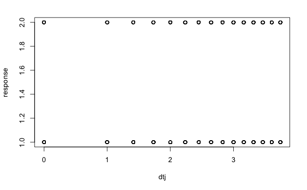

`dtj` appears to have no correlated with response.

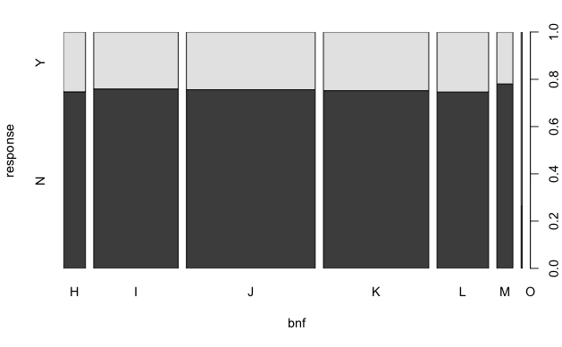

bnf factors are uniform across results thus providingNoInformation.

> Perform principal components analysis of this data (do you need to scale it prior to that? how would you represent multilevel categorical attributes to be used as inputs for PCA?) and plot observations in the space of the first few principal components indicating levels of some of the categorical attributes of your choosing by the color/shape of the symbol.

```r
# FIXME: turn off text wrapping in R Console output
# options(width=10000)

# Core plotting lib
px <- prcomp(as.data.frame(finalExamDatNumeric), retx=TRUE, scale=TRUE)
```

[output not shown]

```r
px
```

[output not shown]

```r
#plot(px, names.arg = colnames(px[["x"]]))
plot(px)
```

[output not shown]

```r
summary(px)
```

[output not shown]

```r
# GG Biplot
library(ggbiplot)
ggbiplot(px)
```

[output not shown]

```r
# Yet another PCA plotting lib
library(devtools)
install_github('sinhrks/ggfortify')
```

```
## Skipping install of 'ggfortify' from a github remote, the SHA1 (e9c1332c) has not changed since last install.
##   Use `force = TRUE` to force installation
```

```r
library(ggfortify); library(ggplot2)
```

# Problem 2: logistic regression (20 points)

> Develop logistic regression model of the outcome `response` as a function of multiple predictors in the model. Which variables are significantly associated with the outcome? Test model performance on multiple splits of data into training and test subsets and summarize it in terms of accuracy/error/sensitivity/specificity.

```
## [1] "Iteration #:  1"
```

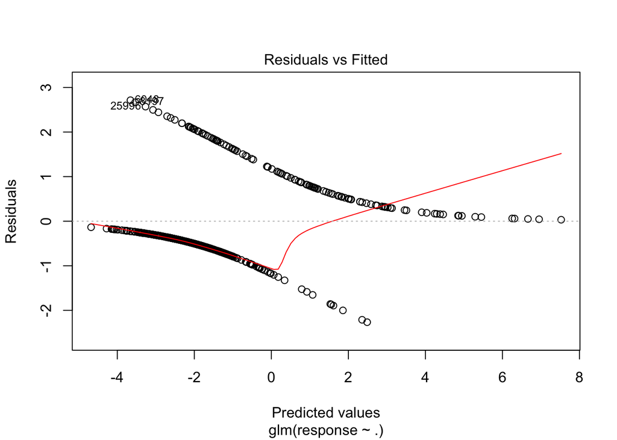

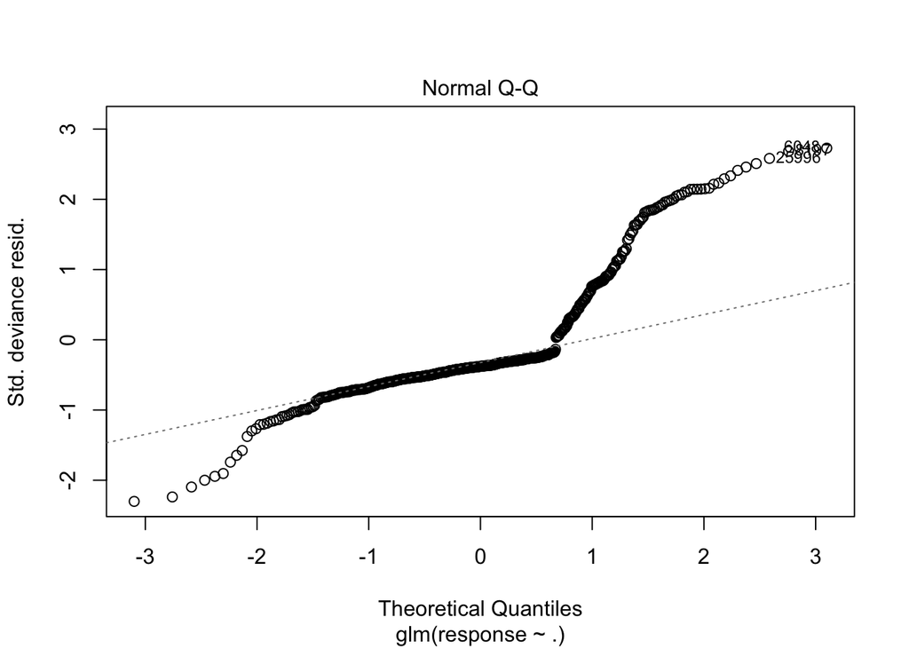

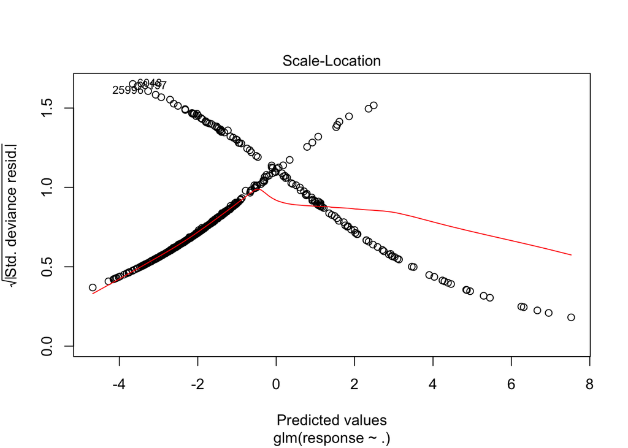

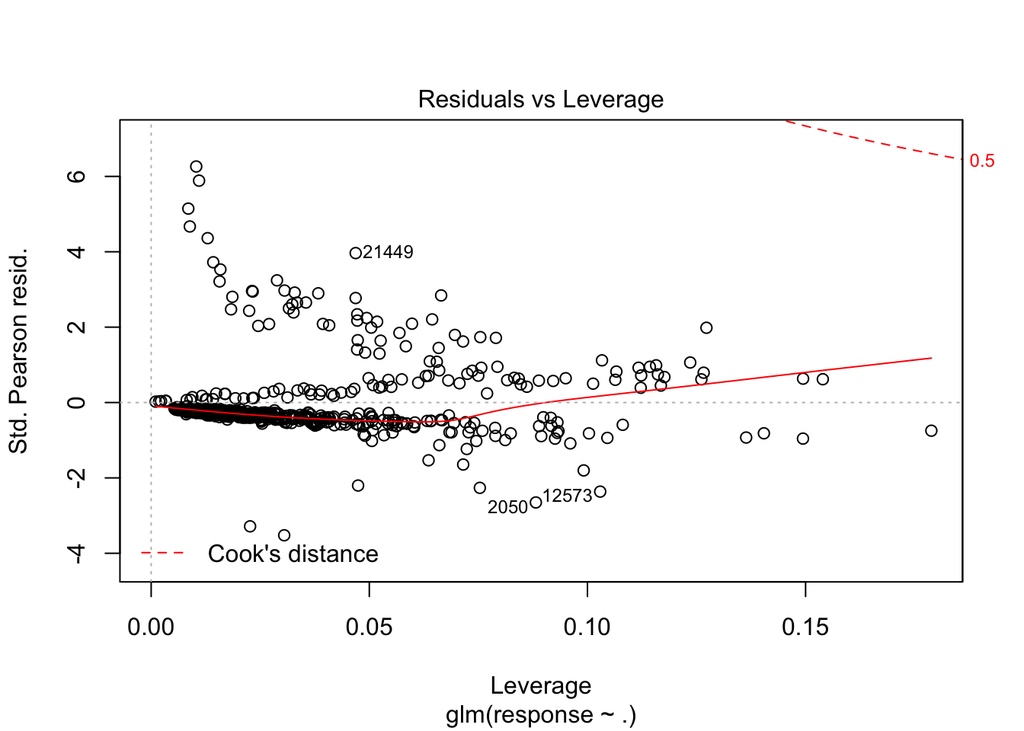

```
## [1] "Accuracy:  0.0735009671179884"
## [1] "Sensitivity:  0.888888888888889"
## [1] "Specificity:  0.157142857142857"
## [1] "Precision:  0.119402985074627"
## [1] "Iteration #:  2"
```

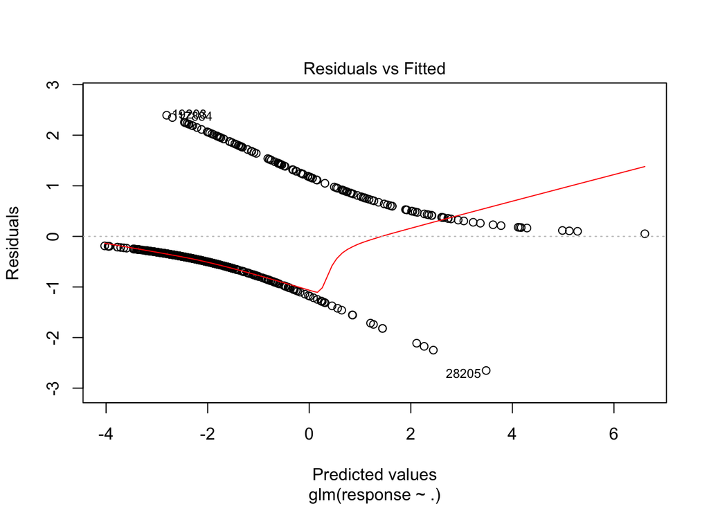

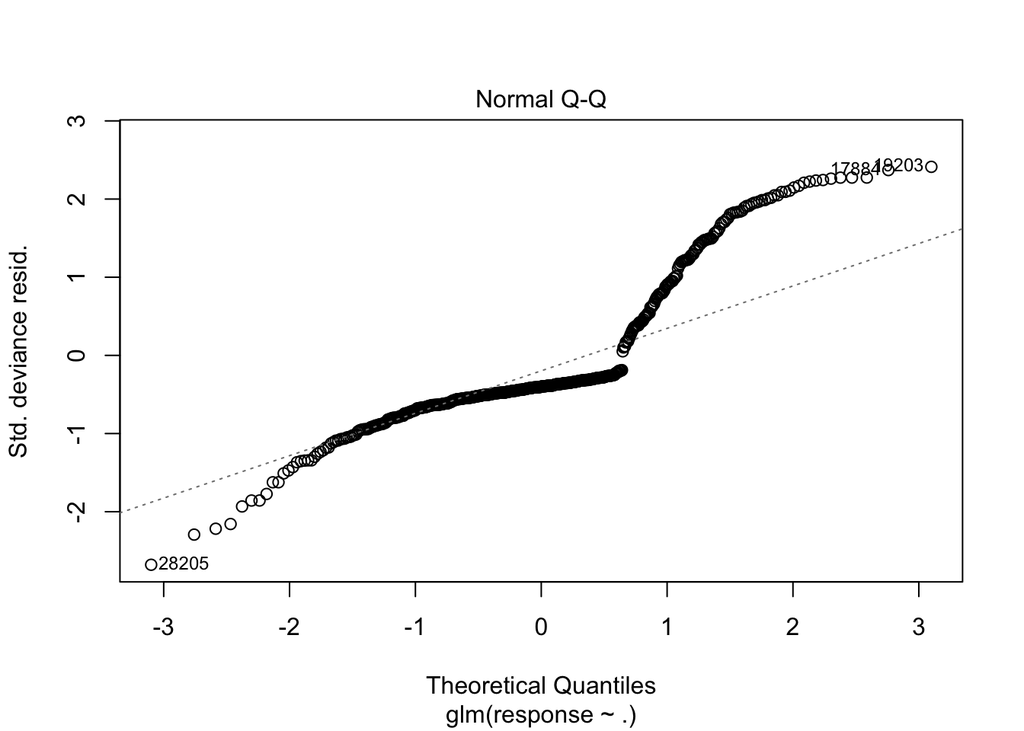

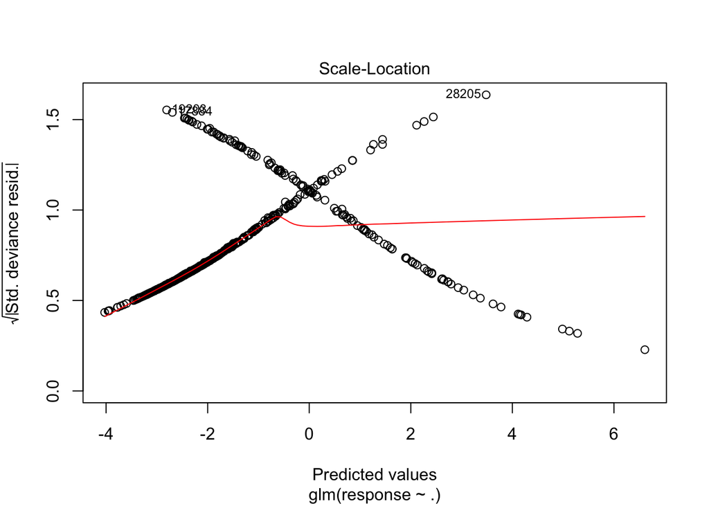

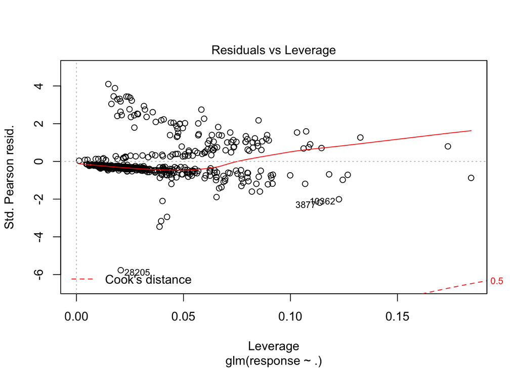

```
## [1] "Accuracy:  0.0367504835589942"
## [1] "Sensitivity:  0.9"
## [1] "Specificity:  0.0854700854700855"
## [1] "Precision:  0.0775862068965517"
## [1] "Iteration #:  3"
```

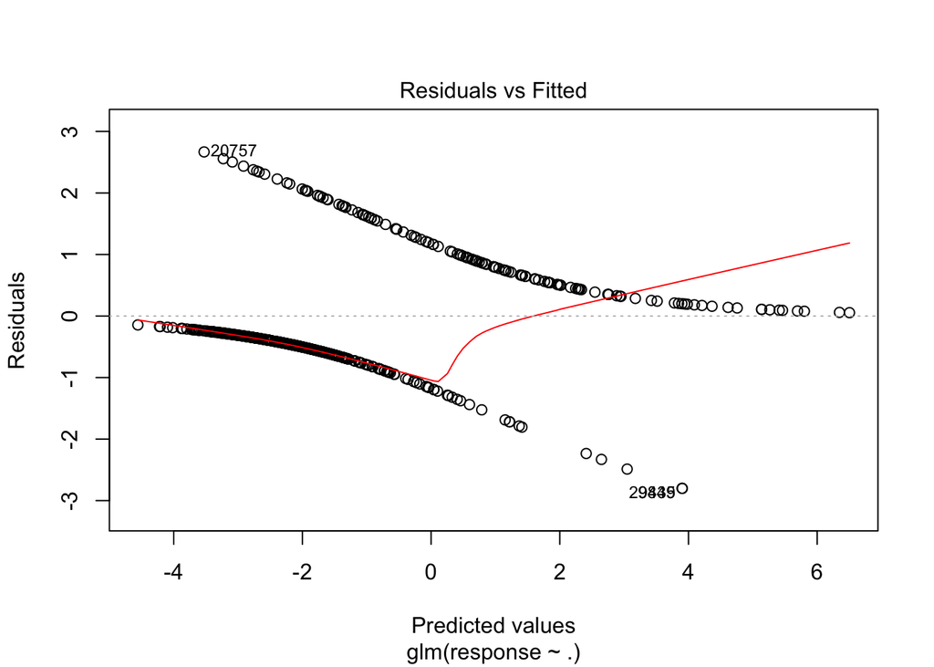

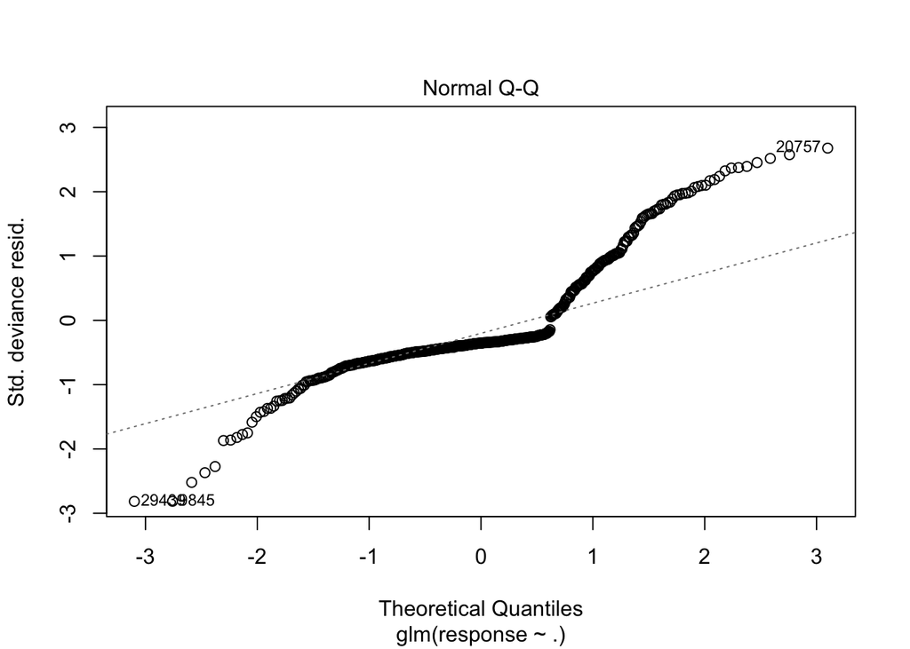

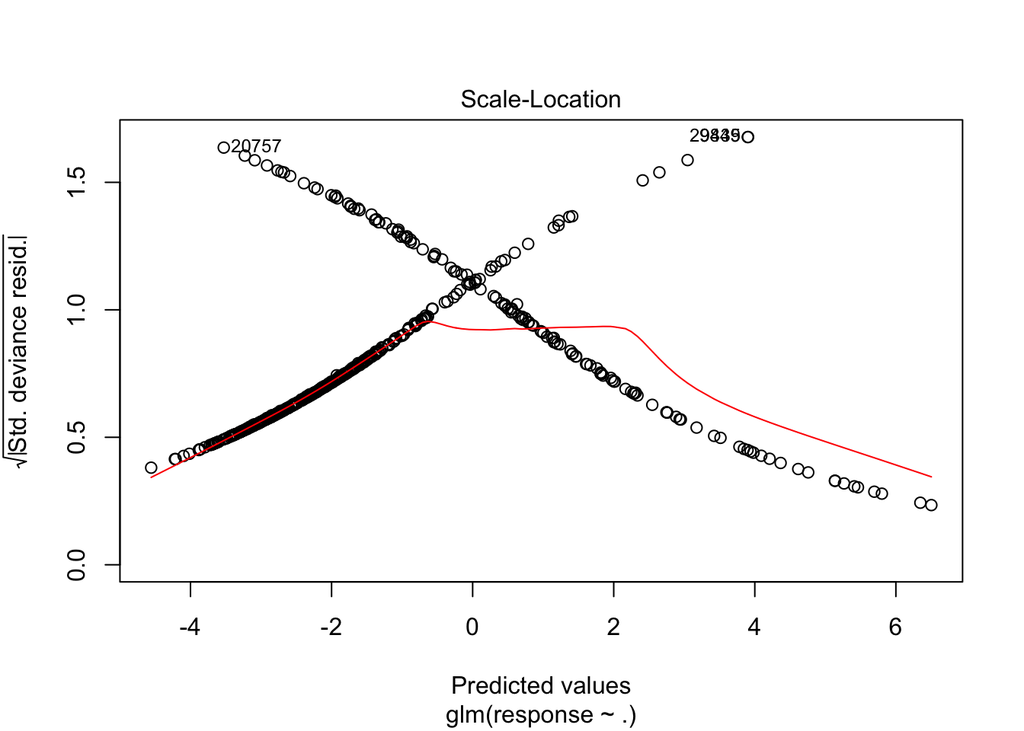

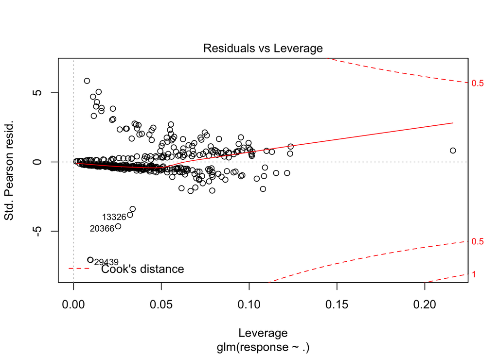

```
## [1] "Accuracy:  0.0541586073500967"
## [1] "Sensitivity:  0.8"
## [1] "Specificity:  0.110344827586207"
## [1] "Precision:  0.0851063829787234"
```

```r
#mylogit <- glm(as.numeric(response) ~ ., data = finalExamDatNumeric, family = "binomial")
#mylogit <- glm(lapply(finalExamDatNumeric$response, FUN = function(x) x-1) ~ ., data = finalExamDatNumeric, family = "binomial")
#summary(mylogit)

for (i in 1:3) {

  print(paste("Iteration #: ", i))

  r <- getTestData(splitBy = 30)
  xyzTest    = r$xyzTest
  xyzTrain   = r$xyzTrain
  classTest  = r$classTest
  classTrain = r$classTrain

  myLR <- glm(response ~., data = as.data.frame(cbind(xyzTrain, response = classTrain)), family = "binomial")
  plot(myLR)
  pred <- predict(myLR, newdata = as.data.frame(xyzTest))
  tbl <- table(classTest, round(pred))

  printAllConfusionMatrixStats(tbl)
}
```

Execution [wall clock] time for this code chunk: 1.87 seconds

```r
# wi             <2e-16 ***
# sb             <2e-16 ***
# qh             <2e-16 ***
# np           1.21e-08 ***
# (Intercept)  4.81e-06 ***
# xt           9.08e-05 ***
# tdt           0.00496 **
# ku            0.00485 **
# sci           0.03704 *
# dtj           0.02077 *

significantPredictors <- c("wi", "sb", "qh", "np", "xt", "tdt", "ku", "sci", "dtj")
```

Execution [wall clock] time for this code chunk: 0 seconds

## Extra points problem: interaction terms (5 extra points)

> Assess the impact/significance of pairwise interaction terms for all pairwise combinations of covariates used in the model and report the top ten that most significantly improve model fit.

```r
# Plot predictors with response
for (i in colNames) {
  for (j in colNames) {
    plot(finalExamDat[,i], finalExamDat[,j], xlab = i, ylab = j)
    myLM <- lm(response ~ i * j, finalExamDatNumeric)
    abline(myLM)

    # Plot each scatterplot in a separate pane
    dev.off()

    # If abline plots show non-parallel lines, we may have an interaction
  }
}
```

Execution [wall clock] time for this code chunk: 0 seconds

# Problem 3: linear discriminant analysis (15 points)

> Fit linear discriminant analysis model of the outcome `response` as a function of the rest of covariates in the dataset. Feel free to decide whether you want to use all of them or a subset of those. Test resulting model performance on multiple splits of the data into training and test subsets, summarize it in terms of accuracy/error/sensitivity/specificity and compare them to those obtained for logistic regression.

```
## [1] "Iteration #:  1"
```

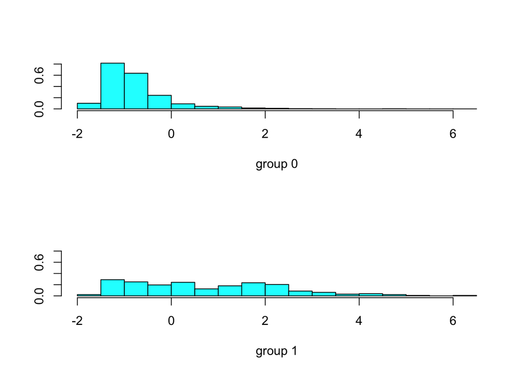

```
## [1] "Accuracy:  0.838334946757018"
## [1] "Sensitivity:  0.48605577689243"
## [1] "Specificity:  0.951406649616368"
## [1] "Precision:  0.7625"
## [1] "Iteration #:  2"
```

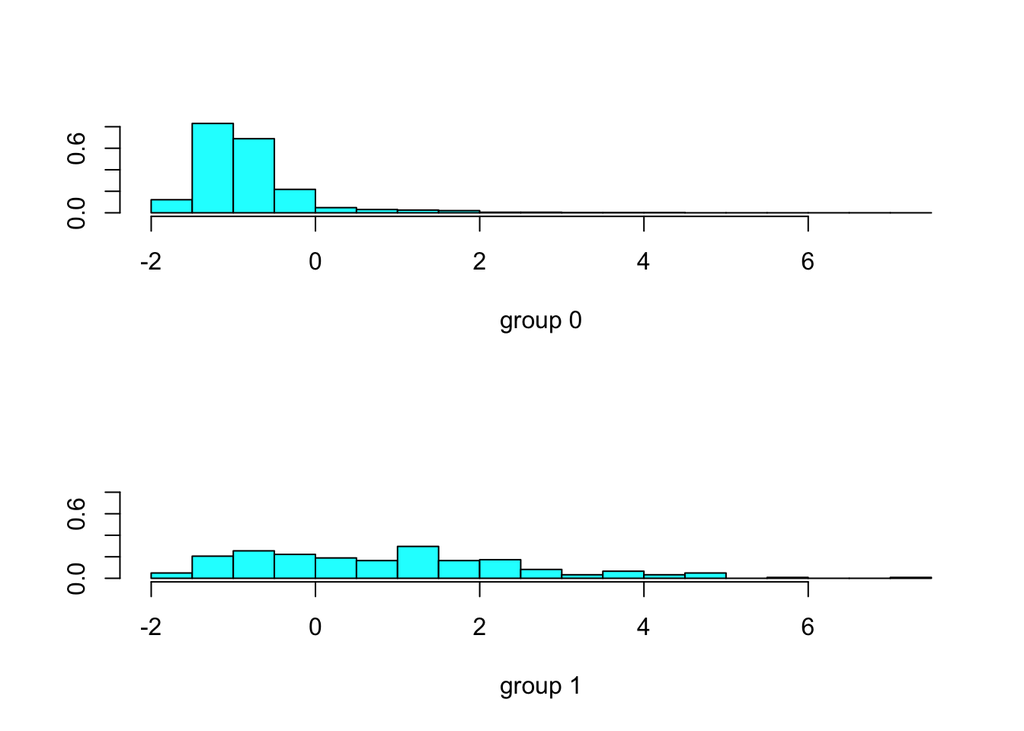

```
## [1] "Accuracy:  0.846079380445305"
## [1] "Sensitivity:  0.531835205992509"
## [1] "Specificity:  0.955613577023499"
## [1] "Precision:  0.806818181818182"
## [1] "Iteration #:  3"
```

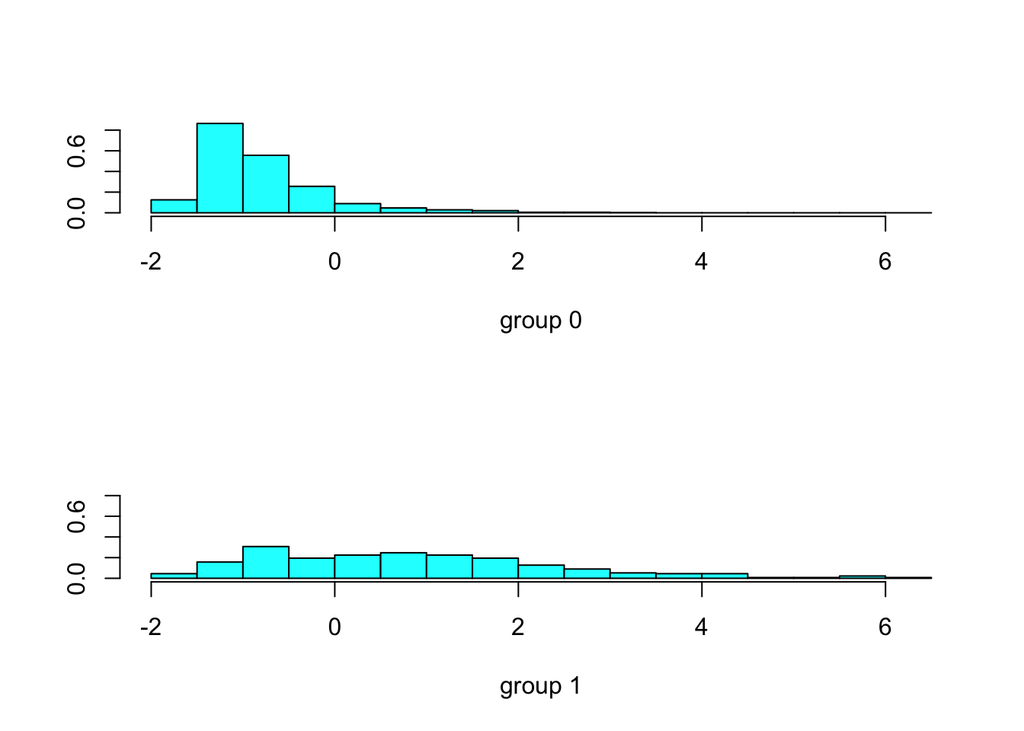

```
## [1] "Accuracy:  0.854791868344627"
## [1] "Sensitivity:  0.485232067510549"
## [1] "Specificity:  0.964824120603015"
## [1] "Precision:  0.804195804195804"
```

```r
library(MASS)

for (i in 1:3) {

  print(paste("Iteration #: ", i))

  r <- getTestData(splitBy = 15)
  xyzTest    = r$xyzTest[, significantPredictors]
  xyzTrain   = r$xyzTrain[, significantPredictors]
  classTest  = r$classTest
  classTrain = r$classTrain

  myLDA <- lda(response ~., data=as.data.frame(cbind(xyzTrain, response = classTrain)))
  plot(myLDA)
  pred <- predict(myLDA, newdata = as.data.frame(xyzTest))
  tbl <- table(classTest, pred$class)

  printAllConfusionMatrixStats(tbl)
}
```

Execution [wall clock] time for this code chunk: 0.53 seconds

Error rate of roughly 15%.

# Problem 4: random forest (15 points)

> Develop random forest model of outcome `response`. Present variable importance plots and comment on relative importance of different attributes in the model. Did attributes showing up as more important in random forest model also appear as significantly associated with the outcome by logistic regression? Test model performance on multiple splits of data into training and test subsets, compare test and out-of-bag error estimates, summarize model performance in terms of accuracy/error/sensitivity/specificity and compare to the performance of logistic regression and LDA models above.

```r
library(randomForest)
for (i in 1:3) {

  print(paste("Iteration #: ", i))

  r <- getTestData(splitBy = 15)
  xyzTest    = r$xyzTest
  xyzTrain   = r$xyzTrain
  classTest  = r$classTest
  classTrain = r$classTrain

  rfRes <- randomForest(xyzTrain, classTrain)
  pred <- predict(rfRes, newdata=xyzTest)

  # FIXME: Why do we need to round here?
  tbl <- table(classTest, round(pred))
  printAllConfusionMatrixStats(tbl)
}
```

```
## [1] "Iteration #:  1"
```

```
## [1] "Accuracy:  0.862536302032914"
## [1] "Sensitivity:  0.584677419354839"
## [1] "Specificity:  0.95031847133758"
## [1] "Precision:  0.78804347826087"
## [1] "Iteration #:  2"
```

```
## [1] "Accuracy:  0.847047434656341"
## [1] "Sensitivity:  0.592057761732852"
## [1] "Specificity:  0.94047619047619"
## [1] "Precision:  0.784688995215311"
## [1] "Iteration #:  3"
```

```
## [1] "Accuracy:  0.864472410454985"
## [1] "Sensitivity:  0.559322033898305"
## [1] "Specificity:  0.954830614805521"
## [1] "Precision:  0.785714285714286"
```

```r
#hist(pred, labels = TRUE)
```

Execution [wall clock] time for this code chunk: 5.93 seconds

Error rate of roughly 15% is about the same as LDA.

# Problem 5: SVM (20 points)

> Develop SVM model of categorical outcome `response` deciding on the choice of kernel, cost, etc. that appear to yield better performance. Test model performance on multiple splits of data into training and test subsets, summarize model performance in terms of accuracy/error/sensitivity/specificity and compare to the performance of the rest of the models developed above (logistic regression, LDA, random forest).

```r
library(e1071)

for (i in 1:3) {

  print(paste("Iteration #: ", i))

  r <- getTestData(splitBy = 10)
  xyzTest    = r$xyzTest
  xyzTrain   = r$xyzTrain
  classTest  = r$classTest
  classTrain = r$classTrain

  # FIXME: try using response factors (instead of response integers)
  svmRes <- svm(xyzTrain, classTrain, kernel="radial")
  pred <- predict(svmRes, newdata=xyzTest)
  # FIXME: Why do we need to round here?
  tbl <- table(classTest, round(pred))
  printAllConfusionMatrixStats(tbl)
}
```

```
## [1] "Iteration #:  1"
## [1] "Accuracy:  0.856774193548387"
## [1] "Sensitivity:  0.542857142857143"
## [1] "Specificity:  0.960515021459228"
## [1] "Precision:  0.819607843137255"
## [1] "Iteration #:  2"
## [1] "Accuracy:  0.843870967741935"
## [1] "Sensitivity:  0.474801061007958"
## [1] "Specificity:  0.962489343563512"
## [1] "Precision:  0.802690582959641"
## [1] "Iteration #:  3"
## [1] "Accuracy:  0.86"
## [1] "Sensitivity:  0.541884816753927"
## [1] "Specificity:  0.964041095890411"
## [1] "Precision:  0.831325301204819"
```

Execution [wall clock] time for this code chunk: 0.96 seconds

# Problem 6: predictions for test dataset (10 points)

## Problem 6a: compare logistic regression, LDA, random forest and SVM model performance (3 points)

> Compare performance of the models developed above (logistic regression, LDA, random forest, SVM) in terms of their accuracy, error and sensitivity/specificity. Comment on differences and similarities between them.

## Problem 6b: make predictions for the **test** dataset (3 points)

> Decide on the model that performs the best and use it to make predictions for the **test** dataset. This is the dataset that is provided separately from training data without the outcome `response` that we are modeling here. Upload resulting predictions in comma-separated values (CSV) format into the Canvas website. Please check sample files with test dataset predictions for the expected format of the *.csv file with predictions: your submission must be in precisely the same format – two and only two columns, first column - ids of the test observations (“id” column in test dataset), second - predictions as Y/N calls (not 0/1, 1/2, true/false, etc.). The name of the second column of predictions is what will be used in leaderboard as its name.

```r
# Use the whole dang dataset
#r <- getTestData(splitBy = 100)  # Attempt 1

# Use *ALL* data as training data
r <- getTestData(splitBy = 1, splitTrainingAndTestBy = 1)
xyzTest    = r$xyzTest
xyzTrain   = r$xyzTrain
classTest  = r$classTest
classTrain = r$classTrain

competitionData <- read.csv("final-data-test.csv", sep=",")
competitionDataNumeric <- convertFactorsToNumbers(competitionData)

rfRes <- randomForest(xyzTrain, as.numeric(classTrain))
pred <- predict(rfRes, newdata=competitionDataNumeric)

# FIXME: Remove leftmost column line numbers from .csv file
write.csv(cbind("id" = competitionData[, "id"], "King_Louis" = lapply(round(pred), FUN = function(x) ifelse(x < 1, "N", "Y"))), file = "predictions-kl.csv")
```

Execution [wall clock] time for this code chunk: 0 seconds

## Problem 6c: get better than coin flip by 10% (4 points)

> This is not really a problem *per se* but rather a criterion that we will go by when assessing quality of your predictions for the test dataset. You get these four points if your predictions for **test** dataset are better than those obtained from a fair coin flip (already shown in leaderboard and as examples of the file format for predictions upload) by at least 10% on **all** four metrics shown in the leaderboard (accuracy, sensitivity, specificity and precision). But then predictions by the coin flip should not be very difficult to improve upon.

Completed on 16 December, 2019:

CSCI E-63C: Final Exam: Test Predictions Leaderboard

```r
# -----+----------------+-------+----------+-------------+-------------+----------
# rank | Submission     | N     | Accuracy | Sensitivity | Specificity | Precision
# -----+----------------+-------+----------+-------------+-------------+----------
# 1    | jrs_2019_12_16 | 15498 | 90.46974 | 79.11679    | 94.10512    | 81.12384
# 2    | jdprf2         | 15498 | 90.35359 | 77.06837    | 94.60772    | 82.06799
# 3    | RaNdOmFoReSt   | 15498 | 90.33424 | 77.20138    | 94.53957    | 81.90799
# ...
# 24   | King_Louis     | 15498 | 89.20506 | 71.69460    | 94.81216    | 81.56780
# ...
# 56   | CoinFlip       | 15498 | 49.72254 | 50.09311    | 49.60388    | 24.14412
# -----+----------------+-------+----------+-------------+-------------+----------
```

*Updated on 2019-12-16 19:04:05*

# Extra 5 points: KNN model

> Develop KNN classifiers for various values of $K$ and compare their performance to that from the rest of the models evaluated herein. The challenges associated with this task include: a) handling the increase in computational demands of KNN models with the increase in the size of the data, and b) deciding on the choice of the distance that is suitable for a dataset with categorical attributes.

```r
library(class)

# Use *ALL* data as training data
r <- getTestData(splitBy = 30, splitTrainingAndTestBy = 2)
xyzTest    = r$xyzTest
xyzTrain   = r$xyzTrain
classTest  = r$classTest
classTrain = r$classTrain

# for (kVal in c(1,2,5,10,20,40,80)) {
for (kVal in c(1,2,5,10,20,40,80)) {

  print(paste("K: ", kVal))

  # FIXME: Why such dreadful sensitivity?
  knnRes <- knn(xyzTrain, xyzTest, classTrain, k = kVal)
  tbl <- table(classTest, knnRes)
  printAllConfusionMatrixStats(tbl)
}
```

```
## [1] "K:  1"
## [1] "Accuracy:  0.642166344294004"
## [1] "Sensitivity:  0.285714285714286"
## [1] "Specificity:  0.748743718592965"
## [1] "Precision:  0.253731343283582"
## [1] "K:  2"
## [1] "Accuracy:  0.618955512572534"
## [1] "Sensitivity:  0.260504201680672"
## [1] "Specificity:  0.726130653266332"
## [1] "Precision:  0.221428571428571"
## [1] "K:  5"
## [1] "Accuracy:  0.684719535783366"
## [1] "Sensitivity:  0.126050420168067"
## [1] "Specificity:  0.851758793969849"
## [1] "Precision:  0.202702702702703"
```

[output cut: 20 more lines]

Execution [wall clock] time for this code chunk: 0.13 seconds

`k = 20` seems to outperform the other k values (e.g., 1, 2, 5, 10, 40, or 80).

# Extra 10 points: neural network model

> Experiment with fitting neural network models of categorical outcome `response` for this data and evaluate their performance on different splits of the data into training and test. Compare model performance to that for the rest of classifiers developed above.

```r
library(neuralnet)
library(BBmisc)
r <- getTestData(splitBy = 30, splitTrainingAndTestBy = 2)
xyzTest    = r$xyzTest
xyzTrain   = r$xyzTrain
classTest  = r$classTest
classTrain = r$classTrain

#for (hA in c(1,3,5)) {
for (hA in c(10)) {

  nnRes <- neuralnet(response ~ ., lifesign = "minimal", data = cbind(scale(xyzTrain), "response" = classTrain),
                     learningrate = 0.01, algorithm = "backprop", hidden = c(10, 10), rep = 1, stepmax=1e+05,
                     threshold = 0.01, linear.output = FALSE, err.fct = 'ce')
  prediction <- predict(nnRes, newdata = xyzTest)
  tbl <- table(classTest, round(prediction))
  print(paste("Accuracy: ", computeAccuracy(tbl)))
}
```

```
## hidden: 10, 10 thresh: 0.01 rep: 1/1 steps:
```

```
##   13197  error: 0.08682  time: 6.35 secs
```

```
## [1] "Accuracy:  0.736943907156673"
```

Execution [wall clock] time for this code chunk: 6.48 seconds

# An afterword on the computational demands of the final exam

> Because during previous offerings of this course there were always several posts on piazza regarding how long it takes to fit various classifiers to the final exam dataset we have added this note here.

> First of all, we most definitely do *not* expect you to *have* to buy capacity from AWS to complete this assignment. You certainly can if you want to, but this course is not about that and this dataset is really not *that* big to require it. Something reasonable/useful can be accomplished for this data with middle of the road hardware. For instance, knitting of the entire official solution for the final exam on 8Gb RAM machine with two i5-7200u cores takes about an hour using single-threaded R/Rstudio and this includes both extra points problems as well as various assessments of the performance of different models as function of data size and so on.

> Second, your solution should not take hours and hours to compile. If it does, it could be that it is attempting to do too much, or something is implemented inefficiently, or just plain incorrectly - it is impossible for us to comment on this until we see the code when we grade it. In general, it is often very prudent to “start small” – fit your model on a random subset of data small enough for the model fitting call to return immediately, check how model performance (both in terms of error and time it takes to compute) scales with the size of the data you are training it on (as you increase it in size, say, two-fold several times), for tuning start with very coarse grid of parameter values and given those results decide what it right for you, etc.

> Lastly, making the decision about what is right for the problem at hand, how much is enough, etc. is inherent in this line of work. If you choose to conduct model tuning on a subset of the data - especially if you have some assessment of how the choice of tuning parameter and test error is affected by the size of training dataset - it could be a very wise choice. If it is more efficient for you to knit each problem separately, by all means feel free to do that - just remember to submit each .Rmd and HTML file that comprises your entire solution. On that note, if you end up using any of the unorthodox setups for your calculations (e.g. AWS, parallel processing, multiple machines, etc. - none of which are essential for solving it correctly) please be sure that when we grade we have every relevant piece of code available - we won’t be able to grade your work if we are not clear about how the results were obtained.

> In the end, the final exam asks you to assess performance of several classification technologies on a new dataset, decide on which classifier is the best and use it to make predictions for the test data. It is very much up to you how exactly you want to go about it. There could be many versions of correct and informative solution for that (as there could be just as many if not more that are completely wrong).

> As always, best of luck - we are practically done here!